# Juan Francisco Cisneros

## Deber 2

1. Implementación de Genetic Algorithm (GA): Escriba una implementación de algoritmos genéticos que permita tener una representación binaria de cada cromosoma, y que reciba hiperparámetros como: número de bits para el cromosoma, probabilidad de mutación, tamaño de población, función de fitness, tamaño de la élite para generación de la siguiente población, criterio de evaluación para ordenar y número máximo de iteraciones/épocas. Y con este algoritmo, encuentre soluciones para los siguientes problemas.
- Función de Beale: tal como trabajaron previamente en los ejercicios de clase. Asegúrense que su representación cromosómica permita tener de forma efectiva números negativos y números decimales.

```python
import numpy as np
import random

# Función de Beale
def beale(x, y):
    return (1.5 - x + x * y) ** 2 + (2.25 - x + x * y ** 2) ** 2 + (2.625 - x + x * y ** 3) ** 2

# Función para inicializar la población
def inicializarPoblacion(tamanoPoblacion, longitudCromosoma):
    return np.random.randint(2, size=(tamanoPoblacion, longitudCromosoma))

# Función para decodificar un cromosoma
def decodificar(cromosoma, minimo, maximo):
    decimal = int("".join(str(bit) for bit in cromosoma), 2) # Convierte el cromosoma que es una lista a un número decimal
    return minimo + decimal * (maximo - minimo) / (2**len(cromosoma) - 1)

# Función para evaluar el fitness de la población
def evaluarFitness(poblacion, minimo, maximo):
    fitness = []
    for cromosoma in poblacion:
        x = decodificar(cromosoma[:len(cromosoma)//2], minimo, maximo)
        y = decodificar(cromosoma[len(cromosoma)//2:], minimo, maximo)
        fitness.append(-beale(x, y))  # Maximizar el fitness es lo mismo que minimizar la función de Beale
    return np.array(fitness)

# Función para seleccionar los padres para el cruce
def seleccionarPadres(poblacion, fitness, numPadres):
    padres = np.random.choice(np.arange(len(poblacion)), size=numPadres, p=fitness / fitness.sum(), replace=False)
    return [poblacion[i] for i in padres]

# Función para realizar el cruce
def cruzar(padre1, padre2):
    puntoCruce = random.randint(1, len(padre1) - 1)
    hijo1 = np.concatenate((padre1[:puntoCruce], padre2[puntoCruce:]))
    hijo2 = np.concatenate((padre2[:puntoCruce], padre1[puntoCruce:]))
    return hijo1, hijo2

# Función para realizar la mutación
def mutar(individuo, tasaMutacion):
    for i in range(len(individuo)):
        if random.random() < tasaMutacion:
            individuo[i] = 1 - individuo[i]  # Cambia el bit

def algoritmoGenetico(numeroDimensiones, tamanoPoblacion, longitudCromosoma, maximasIteraciones, tasaMutacion):
    mejoresFitness = []
    # Inicialización
    poblacion = inicializarPoblacion(tamanoPoblacion, longitudCromosoma)
    fitnessPoblacion = evaluarFitness(poblacion, -4.5, 4.5)
    mejorSolucion = poblacion[np.argmax(fitnessPoblacion)]

    # Bucle principal
    for i in range(maximasIteraciones):
        # Selección
        padres = seleccionarPadres(poblacion, fitnessPoblacion, tamanoPoblacion)

        # Cruce
        hijos = []
        for i in range(0, len(padres), 2):
            hijo1, hijo2 = cruzar(padres[i], padres[i+1])
            hijos.append(hijo1)
            hijos.append(hijo2)

        # Mutación
        for hijo in hijos:
            mutar(hijo, tasaMutacion)

        # Actualización de la población
        poblacion = padres + hijos
        fitnessPoblacion = evaluarFitness(poblacion, -4.5, 4.5)

        # Actualización de la mejor solución encontrada
        if np.max(fitnessPoblacion) > np.max(evaluarFitness([mejorSolucion], -4.5, 4.5)):
            mejorSolucion = poblacion[np.argmax(fitnessPoblacion)]

        #Imprimo el fitness de la mejor solución en cada iteración
        print("Mejor Fitness Epoca:", i, ":", -np.max(fitnessPoblacion))
        mejoresFitness.append(-np.max(fitnessPoblacion))
        x = decodificar(mejorSolucion[:len(mejorSolucion)//2], -4.5, 4.5)
        y = decodificar(mejorSolucion[len(mejorSolucion)//2:], -4.5, 4.5)
        print("Mejor solución encontrada:", x, y)





    return mejoresFitness

import matplotlib.pyplot as plt

# Llama a la función principal con parámetros personalizables
mejoresFitness = algoritmoGenetico(numeroDimensiones=2, tamanoPoblacion=100, longitudCromosoma=10, maximasIteraciones=1000, tasaMutacion=0.1)

# Crear el gráfico
plt.figure(figsize=(10, 6))
plt.plot(mejoresFitness)
plt.title('Evolución del fitness')
plt.xlabel('Iteración')
plt.ylabel('Fitness')
plt.show()
```

[output not shown]

- Travelling Salesman Problem: para este problema encuentre un esquema para representar una solución a este problema, y busque soluciones para grafos completamente conectados para tamaños (número de nodos): 50, 100 y 150.

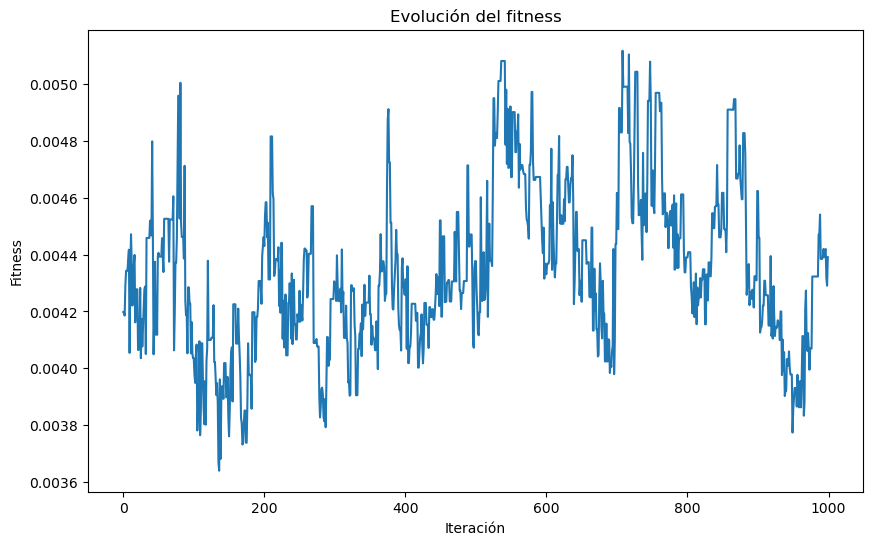

```python
import numpy as np
import random

# Función para calcular la distancia total de un recorrido
def calcularDistanciaTotal(recorrido, matrizDistancias):
    return sum(matrizDistancias[recorrido[i - 1]][recorrido[i]] for i in range(len(recorrido)))

# Función para generar una población inicial
def generarPoblacionInicial(tamano, nCiudades):
    return [random.sample(range(nCiudades), nCiudades) for _ in range(tamano)]

# Función para calcular el fitness de cada individuo de la población
def calcularFitness(poblacion, matrizDistancias):
    return np.array([1 / calcularDistanciaTotal(recorrido, matrizDistancias) for recorrido in poblacion])

# Función para seleccionar los padres para el cruce
def seleccionarPadres(poblacion, fitness, numPadres):
    padres = np.random.choice(np.arange(len(poblacion)), size=numPadres, p=fitness / fitness.sum(), replace=False)
    return [poblacion[i] for i in padres]

# Función para realizar el cruce (operador de orden)
def cruzar(padre1, padre2):
    tamano = len(padre1)
    indice1, indice2 = sorted(random.sample(range(tamano), 2))
    hijo = [-1] * tamano
    hijo[indice1:indice2] = padre1[indice1:indice2]
    for gen in padre2:
        if gen not in hijo:
            for i in range(tamano):
                if hijo[i] == -1:
                    hijo[i] = gen
                    break
    return hijo

# Función para realizar la mutación (intercambio de dos ciudades)
def mutar(recorrido):
    indice1, indice2 = random.sample(range(len(recorrido)), 2)
    recorrido[indice1], recorrido[indice2] = recorrido[indice2], recorrido[indice1]

def algoritmoViajante(nCiudades, tamanoPoblacion, numIteraciones, numPadres, tasaMutacion):
    mejoresFitness = []
    # Generar una matriz de distancias aleatoria
    matrizDistancias = np.random.uniform(1, 10, (nCiudades, nCiudades))
    for i in range(nCiudades):
        for j in range(i + 1, nCiudades):
            matrizDistancias[i][j] = matrizDistancias[j][i]

    # Inicialización
    poblacion = generarPoblacionInicial(tamanoPoblacion, nCiudades)
    fitness = calcularFitness(poblacion, matrizDistancias)
    mejorRecorrido = poblacion[np.argmax(fitness)]

    # Bucle principal
    for i in range(numIteraciones):
        # Selección
        padres = seleccionarPadres(poblacion, fitness, numPadres)

        # Cruce
        hijos = []
        for j in range(0, len(padres), 2):
            hijos.append(cruzar(padres[j], padres[j + 1]))
            hijos.append(cruzar(padres[j + 1], padres[j]))

        # Mutación
        for hijo in hijos:
            if random.random() < tasaMutacion:
                mutar(hijo)

        # Actualización de la población
        poblacion = padres + hijos
        fitness = calcularFitness(poblacion, matrizDistancias)

        # Actualización del mejor recorrido encontrado
        if np.max(fitness) > 1 / calcularDistanciaTotal(mejorRecorrido, matrizDistancias):
            mejorRecorrido = poblacion[np.argmax(fitness)]

        #Imprimo el fitness de la mejor solución en cada iteración
        print("Mejor Fitness Epoca:", i, ":", np.max(fitness))
        mejoresFitness.append(np.max(fitness))
        #Imprimo el mejor recorrido encontrado en cada iteración
        print("Mejor recorrido encontrado:", mejorRecorrido)

    print("Mejor recorrido encontrado:", mejorRecorrido)
    print("Distancia total del mejor recorrido:", calcularDistanciaTotal(mejorRecorrido, matrizDistancias))
    return mejoresFitness

# Llama a la función principal con parámetros personalizables
viajante = algoritmoViajante(nCiudades=50, tamanoPoblacion=50, numIteraciones=1000, numPadres=20, tasaMutacion=0.1)

# Crear el gráfico
plt.figure(figsize=(10, 6))
plt.plot(viajante)
plt.title('Evolución del fitness')
plt.xlabel('Iteración')
plt.ylabel('Fitness')
plt.show()
```

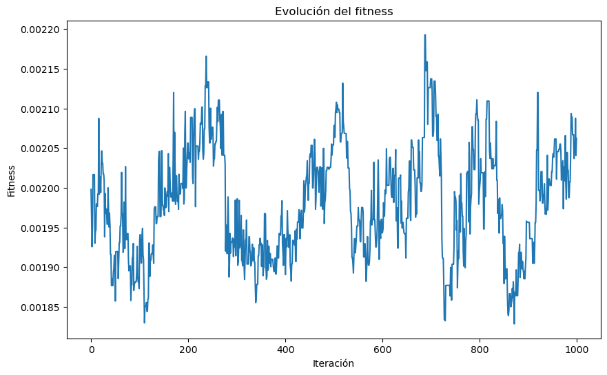

```python
# Llama a la función principal con parámetros personalizables
viajante = algoritmoViajante(nCiudades=100, tamanoPoblacion=50, numIteraciones=1000, numPadres=20, tasaMutacion=0.1)

# Crear el gráfico
plt.figure(figsize=(10, 6))
plt.plot(viajante)
plt.title('Evolución del fitness')
plt.xlabel('Iteración')
plt.ylabel('Fitness')
plt.show()
```

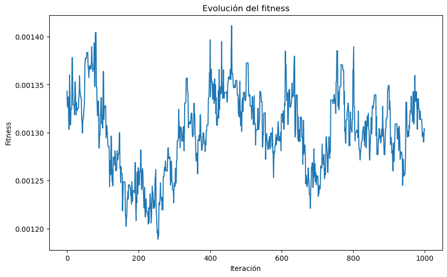

```python
# Llama a la función principal con parámetros personalizables
viajante = algoritmoViajante(nCiudades=150, tamanoPoblacion=50, numIteraciones=1000, numPadres=20, tasaMutacion=0.1)

# Crear el gráfico
plt.figure(figsize=(10, 6))
plt.plot(viajante)
plt.title('Evolución del fitness')
plt.xlabel('Iteración')
plt.ylabel('Fitness')
plt.show()
```

2. Implementación de Particle Swarm Optimization Algorithm (PSO): Escriba una implementación de este algoritmo que permita recibir sus hiperparámetros, el número de partíulas y el total de épocas a correr cada simulación.
- Función de Beale: tal como trabajaron previamente en los ejercicios de clase. Encuentre la solución óptima de la Función de Beale.

```python
import numpy as np
import random
import math

# Función de Beale
def beale(x):
    return (1.5 - x[0] + x[0] * x[1]) ** 2 + (2.25 - x[0] + x[0] * x[1] ** 2) ** 2 + (2.625 - x[0] + x[0] * x[1] ** 3) ** 2

# Función de Rastrigin
def rastrigin(x):
    return 10 * len(x) + sum([(i**2 - 10 * math.cos(2 * math.pi * i)) for i in x])

def pso(epocas, n, peso, c1, c2, min, max, func=beale):
    mejoresFitness = []
    # Inicialización
    particulas = np.random.uniform(min, max, (n, 2)) # inicializamos las particulas
    velocidades = np.zeros((n, 2)) # inicializamos las velocidades
    fitness = np.array([func(x) for x in particulas])
    mejorPosiciones = particulas.copy()
    mejorFitness = fitness.copy()
    mejorGlobal = particulas[np.argmin(fitness)]

    # Bucle principal
    for i in range(epocas):
        for j in range(n):
            # Actualizar la velocidad
            velocidades[j] = peso * velocidades[j] + c1 * random.random() * (mejorPosiciones[j] - particulas[j]) + c2 * random.random() * (mejorGlobal - particulas[j])

            # Actualizar la posición
            particulas[j] += velocidades[j]

            # Actualizar el mejor fitness
            fitnessActual = func(particulas[j])
            if fitnessActual < mejorFitness[j]:
                mejorPosiciones[j] = particulas[j]
                mejorFitness[j] = fitnessActual

                if fitnessActual < func(mejorGlobal):
                    mejorGlobal = particulas[j]

        #Imprimo el fitness de la mejor solución en cada iteración
        print("Mejor Fitness Epoca:", i, ":", fitnessActual)
        mejoresFitness.append(-fitnessActual)
        #Imprimo el mejor recorrido encontrado en cada iteración
        print("Mejor solución encontrada:", mejorGlobal)

    return mejorGlobal, func(mejorGlobal)

solucion, fitness = pso(epocas=1000, n=10, peso=0.5, c1=0.5, c2=0.9, min=-4.5, max=4.5, func=beale)
print("Solucion:", solucion)
print("Fitness:", fitness)

# Crear el gráfico
plt.figure(figsize=(10, 6))
plt.plot(mejoresFitness)
plt.title('Evolución del fitness')
plt.xlabel('Iteración')
plt.ylabel('Fitness')
plt.show()
```

[output not shown]

- Función de Rastrigin para A = 10, y n = 10: para este ejercicio, ejecute el algoritmo de optimización para las condiciones de esta función.

```python
solucion, fitness = pso(epocas=1000, n=10, peso=0.5, c1=0.5, c2=0.9, min=-5.12, max=5.12, func=rastrigin)
print("Solucion:", solucion)
print("Fitness:", fitness)

# Crear el gráfico
plt.figure(figsize=(10, 6))
plt.plot(mejoresFitness)
plt.title('Evolución del fitness')
plt.xlabel('Iteración')
plt.ylabel('Fitness')
plt.show()
```

[output not shown]

Implementación de Ant System Algorithm (ACO-AS): Escriba una implementación para el algoritmo de Ant System para resolver el problema de Travelling Salesman. Es importante que su algoritmo permita definir el número de hormigas y el número de épocas a ejecutar la simulación

- Travelling Salesman Problem: para este problema utilice los mismos grafos generados para la sección (1) de esta tarea. Es decir, grafos de 50, 100 y 150 nodos.

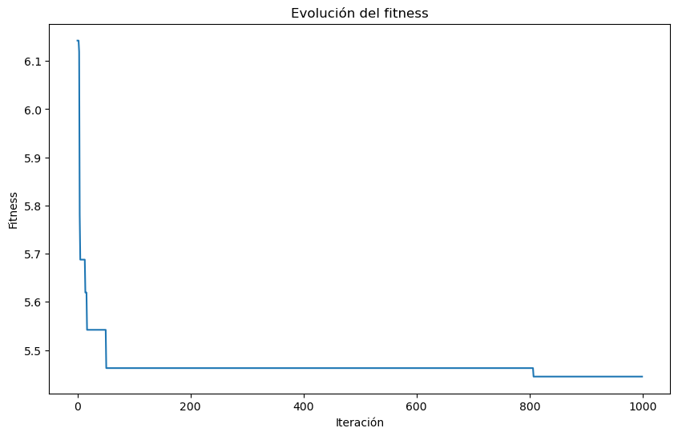

```python
def distanciaEntrePuntos(punto1, punto2):
    return np.sqrt(np.sum((punto1 - [punto2])**2))

def poblacionInicial(ciudades):
    numeroCiudades = len(ciudades)
    feromonas = np.ones((numeroCiudades, numeroCiudades)) # matriz de feromonas
    mejorCamino = None
    mejorDistancia = np.inf # infinita
    return numeroCiudades, feromonas, mejorCamino, mejorDistancia

def seleccionarCiudadNueva(ciudadActual, ciudadesVisitadas, feromona, puntos, alfa,beta):
    noVisitadas = np.where(np.logical_not(ciudadesVisitadas))[0]
    probabilidades = np.zeros(len(noVisitadas)) #probabilidad de ir a una ciudad
    for i, ciudadNoVisitada in enumerate(noVisitadas):
        probabilidades[i] = (feromona[ciudadActual][ciudadNoVisitada] ** alfa) * ((1.0 / distanciaEntrePuntos(puntos[ciudadActual], puntos[ciudadNoVisitada])) ** beta)

    probabilidades = probabilidades / np.sum(probabilidades)
    ciudadNueva = np.random.choice(noVisitadas,p=probabilidades)
    return ciudadNueva


def ant_colony_optimization(ciudades,numeroHormigas,epocas,evaporacion, alfa=1, beta=5):

    mejoresFitness = []

    numeroCuidades, feromonas, mejorCamino, mejorDistancia = poblacionInicial(ciudades)

    for epoca in range(epocas):
        caminos = []
        distancias = []
        for h in range(numeroHormigas):
            visitado = [False] * numeroCuidades
            ciudadActual = np.random.randint(0, numeroCuidades) # seleccionamos una ciudad aleatoria
            visitado[ciudadActual] = True
            camino = [ciudadActual]
            distancia = 0

            # construimos la solucion
            while False in visitado:
                ciudadNueva = seleccionarCiudadNueva(ciudadActual, visitado, feromonas, ciudades, alfa, beta)
                distancia += distanciaEntrePuntos(ciudades[ciudadActual], ciudades[ciudadNueva])
                ciudadActual = ciudadNueva
                visitado[ciudadActual] = True
                camino.append(ciudadActual)

            caminos.append(camino)
            distancias.append(distancia)

            if distancia < mejorDistancia:
                mejorCamino = camino
                mejorDistancia = distancia

        # actualizamos las feromonas
        feromonas = feromonas * evaporacion

        for i in range(len(caminos)):
            for j in range(numeroCuidades - 1):
                feromonas[caminos[i][j]][caminos[i][j + 1]] += 1.0 / distancias[i]

        #Imprimo el fitness de la mejor solución en cada iteración
        print("Mejor Fitness Epoca:", epoca, ":", mejorDistancia)
        mejoresFitness.append(mejorDistancia)
        #Imprimo el mejor recorrido encontrado en cada iteración
        print("Mejor solución encontrada:", mejorCamino)


    return mejorCamino, mejorDistancia, mejoresFitness

cuidades = np.random.rand(50,2)
solucion, fitness, mejoresFitness = ant_colony_optimization(cuidades,numeroHormigas=50,epocas=1000,evaporacion=0.8, alfa=1,beta=5)

# Crear el gráfico
plt.figure(figsize=(10, 6))
plt.plot(mejoresFitness)
plt.title('Evolución del fitness')
plt.xlabel('Iteración')
plt.ylabel('Fitness')
plt.show()
```

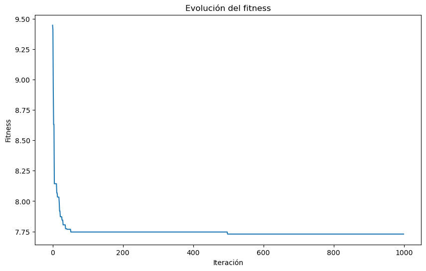

```python
cuidades = np.random.rand(100,2)
solucion, fitness, mejoresFitness = ant_colony_optimization(cuidades,numeroHormigas=50,epocas=1000,evaporacion=0.8, alfa=1,beta=5)

# Crear el gráfico
plt.figure(figsize=(10, 6))
plt.plot(mejoresFitness)
plt.title('Evolución del fitness')
plt.xlabel('Iteración')
plt.ylabel('Fitness')
plt.show()
```

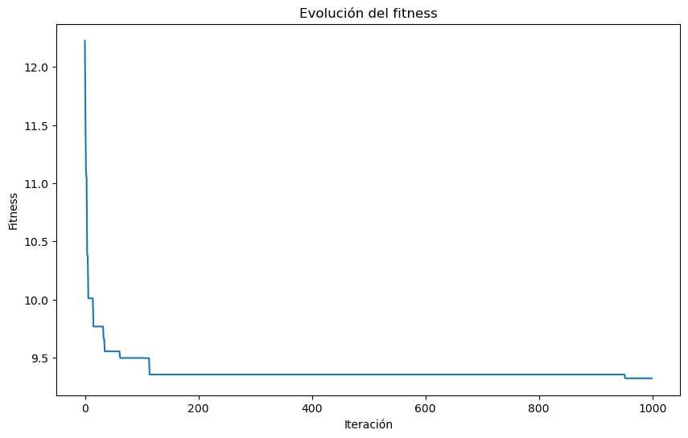

```python
cuidades = np.random.rand(150,2)
ssolucion, fitness, mejoresFitness = ant_colony_optimization(cuidades,numeroHormigas=50,epocas=1000,evaporacion=0.8, alfa=1,beta=5)

# Crear el gráfico
plt.figure(figsize=(10, 6))
plt.plot(mejoresFitness)
plt.title('Evolución del fitness')
plt.xlabel('Iteración')
plt.ylabel('Fitness')
plt.show()
```

4. Implementación de un algoritmo de los siguientes (elegir solo uno): utilizando los papers compartidos en el D2L, elijan un algoritmo de la siguiente lista e impleméntelo para proveer la solución de alguna de los problemas mencionados en esta tarea.
- Artificial Bee Colony Optimization (ABC)
- Grey Wolf Optimizer (GWO) 1 de 2.
- Whale Optimization Algorithm (WAO) *Elegir un problema a optimizar.

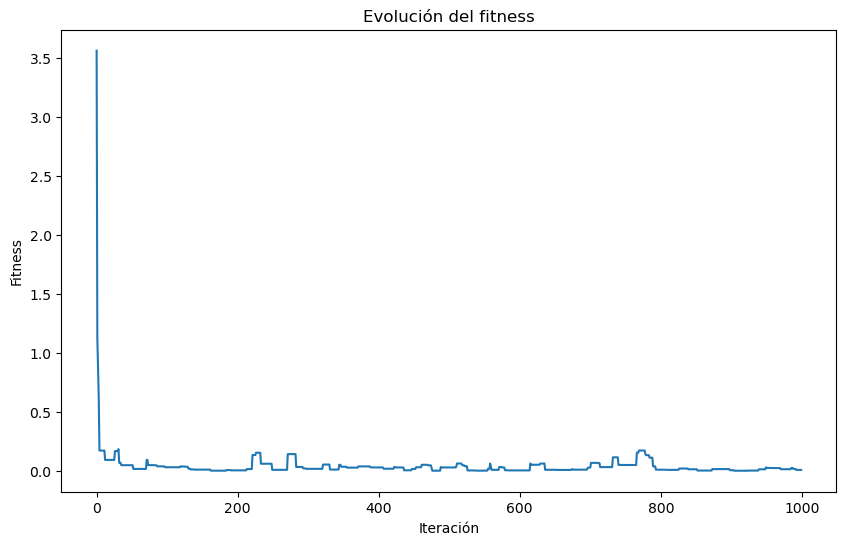

```python
import numpy as np
import random

# Función de Beale
def beale(x, y):
    return (1.5 - x + x * y) ** 2 + (2.25 - x + x * y ** 2) ** 2 + (2.625 - x + x * y ** 3) ** 2

# Función para inicializar la población
def inicializarPoblacion(tamanoPoblacion, numeroDimensiones):
    return np.random.uniform(-4.5, 4.5, (tamanoPoblacion, numeroDimensiones))

# Función para evaluar el fitness de la población
def evaluarFitness(poblacion):
    return np.apply_along_axis(lambda x: beale(x[0], x[1]), 1, poblacion)

# Función para realizar la fase de las abejas empleadas
def abejasEmpleadas(poblacion, fitnessPoblacion, intentos,numeroDimensiones):
    for i in range(len(poblacion)):
        j, k = random.sample(range(numeroDimensiones), 2)
        phi = random.uniform(-1, 1)
        vecino = poblacion[i].copy()
        vecino[j] = poblacion[i, j] + phi * (poblacion[i, j] - poblacion[k, j])
        nuevoFitness = beale(vecino[0], vecino[1])
        if nuevoFitness < fitnessPoblacion[i]:
            poblacion[i] = vecino
            fitnessPoblacion[i] = nuevoFitness
            intentos[i] = 0
        else:
            intentos[i] += 1


# Función para realizar la fase de las abejas observadoras
def abejasObservadoras(poblacion, fitnessPoblacion, intentos,numeroDimensiones):
    probabilidadSeleccion = fitnessPoblacion / np.sum(fitnessPoblacion)
    i = np.random.choice(len(poblacion), p=probabilidadSeleccion)
    j, k = random.sample(range(numeroDimensiones), 2)
    phi = random.uniform(-1, 1)
    vecino = poblacion[i].copy()
    vecino[j] = poblacion[i, j] + phi * (poblacion[i, j] - poblacion[k, j])
    nuevoFitness = beale(vecino[0], vecino[1])
    if nuevoFitness < fitnessPoblacion[i]:
        poblacion[i] = vecino
        fitnessPoblacion[i] = nuevoFitness
        intentos[i] = 0
    else:
        intentos[i] += 1


# Función para realizar la fase de las abejas exploradoras
def abejasExploradoras(poblacion, fitnessPoblacion, intentos,numeroDimensiones):
    limiteAbandono = 10
    i = np.argmax(intentos)
    if intentos[i] > limiteAbandono:
        poblacion[i] = np.random.uniform(-4.5, 4.5, numeroDimensiones)
        nuevoFitness = beale(poblacion[i, 0], poblacion[i, 1])
        fitnessPoblacion[i] = nuevoFitness
        intentos[i] = 0

def algoritmoAbejas(numeroDimensiones, tamanoPoblacion, maximasIteraciones):
    mejoresFitness = []

    # Inicialización
    poblacion = inicializarPoblacion(tamanoPoblacion, numeroDimensiones)
    fitnessPoblacion = evaluarFitness(poblacion)
    intentos = np.zeros(tamanoPoblacion)
    mejorSolucion = poblacion[np.argmin(fitnessPoblacion)]

    # Bucle principal
    for i in range(maximasIteraciones):
        abejasEmpleadas(poblacion, fitnessPoblacion, intentos, numeroDimensiones)
        abejasObservadoras(poblacion, fitnessPoblacion, intentos,numeroDimensiones)
        abejasExploradoras(poblacion, fitnessPoblacion, intentos,numeroDimensiones)

        # Actualiza la mejor solución encontrada
        if np.min(fitnessPoblacion) < beale(mejorSolucion[0], mejorSolucion[1]):
            mejorSolucion = poblacion[np.argmin(fitnessPoblacion)]

        #Imprimo el fitness de la mejor solución en cada iteración
        print("Mejor Fitness Epoca:", i, ":", np.min(fitnessPoblacion))
        mejoresFitness.append(np.min(fitnessPoblacion))
        #Imprimo el mejor recorrido encontrado en cada iteración
        print("Mejor solución encontrada:", mejorSolucion)

    return mejoresFitness

# Llama a la función principal con parámetros personalizables
abejas = algoritmoAbejas(numeroDimensiones=2, tamanoPoblacion=50, maximasIteraciones=1000)

# Crear el gráfico
plt.figure(figsize=(10, 6))
plt.plot(abejas)
plt.title('Evolución del fitness')
plt.xlabel('Iteración')
plt.ylabel('Fitness')
plt.show()
```

### Para el punto extra

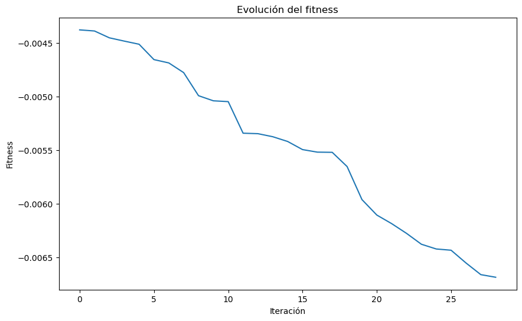

```python
import numpy as np
import random
import matplotlib.pyplot as plt

# Función para calcular la distancia total de un recorrido
def calcularDistanciaTotal(recorrido, matrizDistancias):
    return sum(matrizDistancias[recorrido[i - 1]][recorrido[i]] for i in range(len(recorrido)))

# Función para generar una población inicial
def generarPoblacionInicial(tamano, nCiudades):
    return [random.sample(range(nCiudades), nCiudades) for _ in range(tamano)]

# Función para calcular el fitness de cada individuo de la población
def calcularFitness(poblacion, matrizDistancias):
    return np.array([1 / calcularDistanciaTotal(recorrido, matrizDistancias) for recorrido in poblacion])

# Función para realizar la fase de las abejas empleadas
def abejasEmpleadas(poblacion, fitnessPoblacion, intentos, matrizDistancias):
    for i in range(len(poblacion)):
        j, k = random.sample(range(len(poblacion[i])), 2)
        vecino = poblacion[i].copy()
        vecino[j], vecino[k] = vecino[k], vecino[j]
        nuevoFitness = 1 / calcularDistanciaTotal(vecino, matrizDistancias)
        if nuevoFitness > fitnessPoblacion[i]:
            poblacion[i] = vecino
            fitnessPoblacion[i] = nuevoFitness
            intentos[i] = 0
        else:
            intentos[i] += 1

# Función para realizar la fase de las abejas observadoras
def abejasObservadoras(poblacion, fitnessPoblacion, intentos, matrizDistancias):
    probabilidadSeleccion = fitnessPoblacion / np.sum(fitnessPoblacion)
    i = np.random.choice(len(poblacion), p=probabilidadSeleccion)
    j, k = random.sample(range(len(poblacion[i])), 2)
    vecino = poblacion[i].copy()
    vecino[j], vecino[k] = vecino[k], vecino[j]
    nuevoFitness = 1 / calcularDistanciaTotal(vecino, matrizDistancias)
    if nuevoFitness > fitnessPoblacion[i]:
        poblacion[i] = vecino
        fitnessPoblacion[i] = nuevoFitness
        intentos[i] = 0
    else:
        intentos[i] += 1

# Función para realizar la fase de las abejas exploradoras
def abejasExploradoras(poblacion, fitnessPoblacion, intentos, nCiudades, matrizDistancias):
    i = np.argmax(intentos)
    limiteAbandono = 10
    if intentos[i] > limiteAbandono:
        poblacion[i] = random.sample(range(nCiudades), nCiudades)
        nuevoFitness = 1 / calcularDistanciaTotal(poblacion[i], matrizDistancias)
        fitnessPoblacion[i] = nuevoFitness
        intentos[i] = 0

def algoritmoAbejas(nCiudades, tamanoPoblacion, numIteraciones):
    mejoresFitness = []
    # Generar una matriz de distancias aleatoria
    matrizDistancias = np.random.uniform(1, 10, (nCiudades, nCiudades))
    for i in range(nCiudades):
        for j in range(i + 1, nCiudades):
            matrizDistancias[i][j] = matrizDistancias[j][i]

    # Inicialización
    poblacion = generarPoblacionInicial(tamanoPoblacion, nCiudades)
    fitnessPoblacion = calcularFitness(poblacion, matrizDistancias)
    intentos = np.zeros(tamanoPoblacion)
    mejorRecorrido = poblacion[np.argmax(fitnessPoblacion)]

    for k in range(numIteraciones):
        abejasEmpleadas(poblacion, fitnessPoblacion, intentos, matrizDistancias)
        abejasObservadoras(poblacion, fitnessPoblacion, intentos, matrizDistancias)
        abejasExploradoras(poblacion, fitnessPoblacion, intentos, nCiudades, matrizDistancias)

        # Actualiza la mejor solución encontrada
        if np.max(fitnessPoblacion) > 1 / calcularDistanciaTotal(mejorRecorrido, matrizDistancias):
            mejorRecorrido = poblacion[np.argmax(fitnessPoblacion)]
            # Imprimo el fitness de la mejor solución en cada iteración
            print("Mejor Fitness Epoca:", k, ":", np.max(fitnessPoblacion))
            mejoresFitness.append(-np.max(fitnessPoblacion))
            # Imprimo el mejor recorrido encontrado en cada iteración
            print("Mejor recorrido encontrado:", mejorRecorrido)

    return mejoresFitness

# Llama a la función principal con parámetros personalizables
abejas = algoritmoAbejas(nCiudades=50, tamanoPoblacion=50, numIteraciones=1000)

# Crear el gráfico
plt.figure(figsize=(10, 6))
plt.plot(abejas)
plt.title('Evolución del fitness')
plt.xlabel('Iteración')
plt.ylabel('Fitness')
plt.show()
```

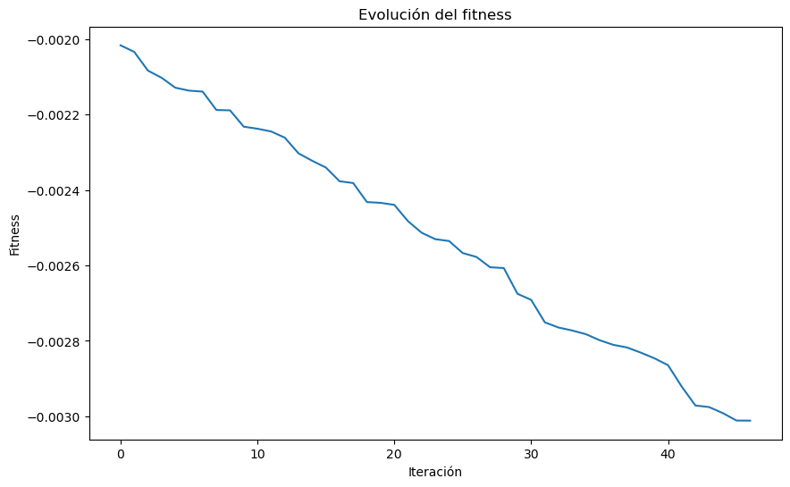

```python
# Llama a la función principal con parámetros personalizables
abejas = algoritmoAbejas(nCiudades=100, tamanoPoblacion=50, numIteraciones=1000)

# Crear el gráfico
plt.figure(figsize=(10, 6))
plt.plot(abejas)
plt.title('Evolución del fitness')
plt.xlabel('Iteración')
plt.ylabel('Fitness')
plt.show()
```

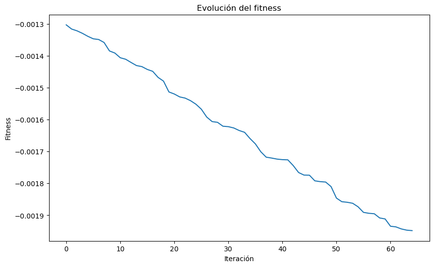

```python
# Llama a la función principal con parámetros personalizables
abejas = algoritmoAbejas(nCiudades=150, tamanoPoblacion=50, numIteraciones=1000)

# Crear el gráfico
plt.figure(figsize=(10, 6))
plt.plot(abejas)
plt.title('Evolución del fitness')
plt.xlabel('Iteración')
plt.ylabel('Fitness')
plt.show()
```

5. Comparar las soluciones de Travelling Salesman Problem GAs vs. ACO-AS En su informe, agregue una tabla de comparación para las soluciones encontradas tanto para Gas como para ACO-AS para los 3 grafos generados. Incluya una discusión de los resultados obtenidos.

#### Según los resultados obtenidos he creado esta tabla para comparar los resultados obtenidos para el problema del Travelling Salesman Problem.

[output not shown]

Como hemos conversado en clase estos algoritmos para este problema en específico son de suma importancia para empresas de logística como amazon o dhl, es por esto que en mi conclusión he querido mencionar que si fuera el caso y yo estaría en una de estas empresas elegiría el algoritmo Bee Colony Optimization para resolver el problema del orden en que se entregan los paquetes por repartidor. Dicho esto es un algoritmo que podría tomar algo de tiempo en correr pero que es posible de computar en dispositivos móviles o en servidores por las noches para que al día siguiente los repartidores tengan una ruta óptima a través de por ejemplo un api call para entregar los paquetes.

# REFERENCIAS

### GENETIC ALGORITHM

- Dr.Panda. (2022, November 23). Binary genetic Algorithm in Python. Learn With Panda. https://learnwithpanda.com/2021/04/19/binary-genetic-algorithm-in-python/
- Bigzhao. (n.d.). GitHub - bigzhao/Binary-Genetic-Algorithm: Binary genetic algorithm in python. GitHub. https://github.com/bigzhao/Binary-Genetic-Algorithm
- Gad, A. F. (2021). Different genetic algorithm representations in Python | Paperspace blog. Paperspace Blog. https://blog.paperspace.com/working-with-different-genetic-algorithm-representations-python/
- Brownlee, J. (2021). Simple genetic algorithm from scratch in Python. MachineLearningMastery.com. https://machinelearningmastery.com/simple-genetic-algorithm-from-scratch-in-python/

### PSO

- Rooy, N. (2016, August 17). Particle Swarm Optimization from Scratch with Python. nathanrooy.github.io. https://nathanrooy.github.io/posts/2016-08-17/simple-particle-swarm-optimization-with-python/
- Tam, A. (2021). A gentle introduction to particle swarm optimization. MachineLearningMastery.com. https://machinelearningmastery.com/a-gentle-introduction-to-particle-swarm-optimization/

### ACO

- GeeksforGeeks. (2020). Introduction to Ant Colony Optimization. GeeksforGeeks. https://www.geeksforgeeks.org/introduction-to-ant-colony-optimization/
- YouTube. (2023). YouTube. Retrieved October 20, 2023, from https://www.youtube.com/watch?v=u7bQomllcJw.
- YouTube. (2016). YouTube. Retrieved October 20, 2023, from https://www.youtube.com/watch?v=qfeymoF8pb4.
- YouTube. (2018). YouTube. Retrieved October 20, 2023, from https://www.youtube.com/watch?v=783ZtAF4j5g.

### BEE

- Buarque, P. (2018, June 15). A Swarm Intelligence approach to Optimization Problems using the Artificial Bee Colony (ABC) Algorithm. Medium. https://medium.com/cesar-update/a-swarm-intelligence-approach-to-optimization-problems-using-the-artificial-bee-colony-abc-5d4c0302aaa4
- Ram, N. (2022, April 16). How to apply artificial bee colony algorithm to solve unconventional problems. Medium. https://towardsdatascience.com/how-to-apply-artificial-bee-colony-algorithm-to-solve-unconventional-problems-a41c5098eb3a
- Mehta, S., Mehta, S., Mehta, S., & Mehta, S. (2022). Artificial bee colony and its applications to optimization problems. Analytics India Magazine. https://analyticsindiamag.com/artificial-bee-colony-and-its-applications-to-optimization-problems/